# Geometry of Embeddings

Kick-off · Evidence, structure, and meaning in learned representations

21 October 2026

## Who we are

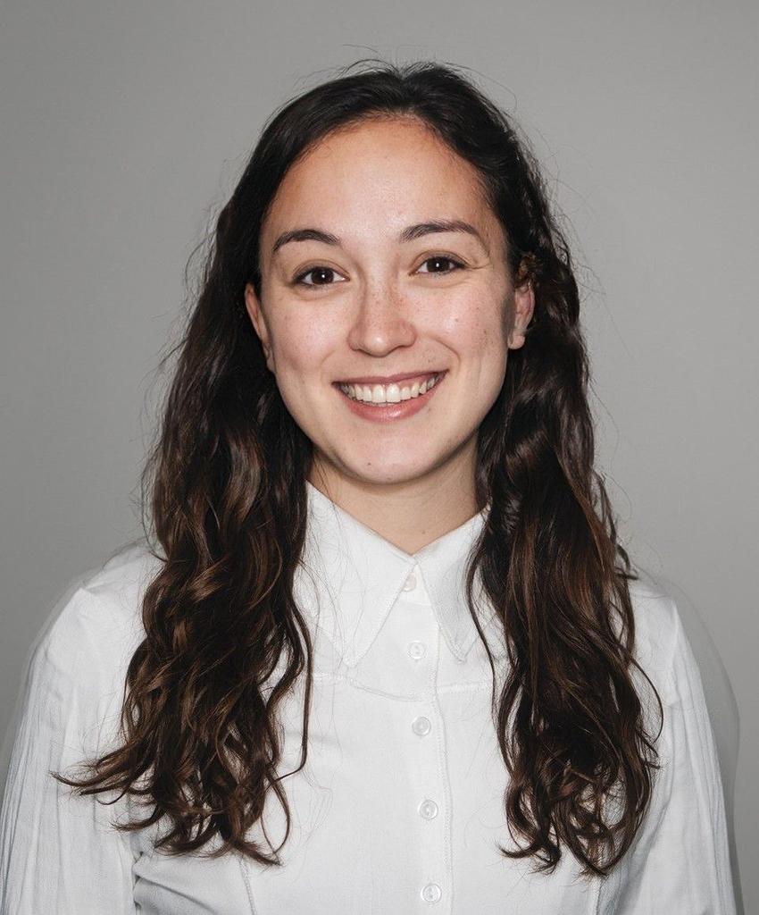

**Helen Alber**  
PhD student since October 2024:  
NLP focus group at SLDS, LMU, and BERD@NFDI  
AG Text Data & Statistical Language Technologies  
before: Statistical Consulting Unit (StaBLab)  
B.Sc. Cognitive Science (Tübingen)  
M.Sc. Statistics and Data Science (LMU)  
interests: NLP, annotation, LLMs in science, philosophy of ML

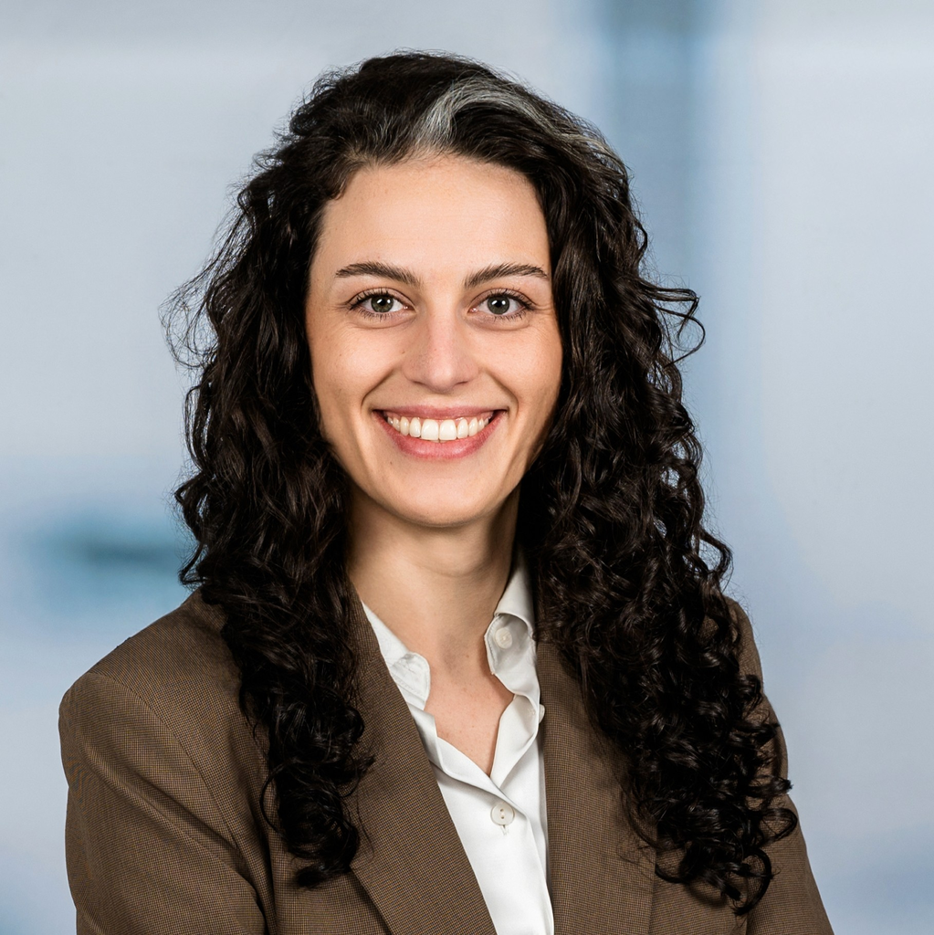

**Laura Braun**  
External PhD student (based at ZITiS) since April 2026 @ LMU  
Before: research associate, University of the Bundeswehr Munich  
M.Sc. Social Data Science (University of Copenhagen)  
Interests: uncertainty quantification in LLMs

## Who we are

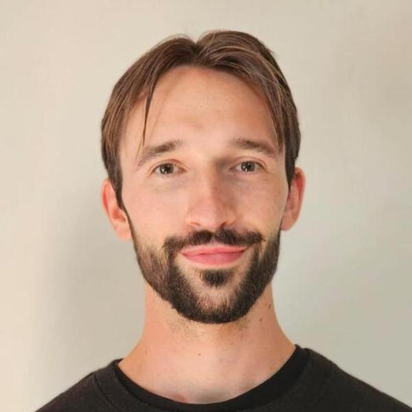

**Leo Kestel**  
SODA group, LMU, since February 2025  
ADA Bayern: data science for public authorities  
before: ML engineer and data scientist at Bytabo, Bamberg  
B.Sc. Psychology, M.Sc. Computer Science (Bamberg)  
interests: neurosymbolic AI, fair representation learning

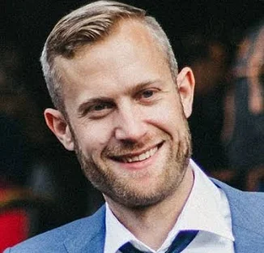

**Fabian Scheipl**  
PD Dr., Department of Statistics, LMU  
leads the Functional Data Analysis group  
models for curves, trajectories and surfaces  
Interested in statistical learning and representation learning

## Today

1. Welcome and Introduction
2. The big question — and why this seminar asks it
3. How the semester is built
4. What you do each week
5. Practice essay, final essays, grading
6. Intro based on *Principles and Practice of Deep Representation Learning*

# The big idea

## Guiding questions

> **What structure do learned representations have,**  
> **how can we know,**  
> **and what follows from apparent agreement across models or modalities?**
- *What structure?* — geometry: similarity, neighbourhoods, directions, features
- *How can we know?* — measurement: metrics, baselines, nulls, robustness
- *What follows?* — interpretation: meaning, grounding, the limits of geometry

## The running case: *Platonic Representation Hypothesis*

**The claim (Huh et al., 2024):**  
capable models converge toward a shared statistical model of reality.

**The evidence:**  
alignment scores between models grow with model capability.

**The critique (2026):**  
after calibration against proper null baselines, the global trend largely disappears.  
One line of work finds only narrower *local-neighbourhood* agreement robust.  
Another finds that this local agreement falls sharply as the evaluation gallery grows.

*Our job:*  
learn enough geometry, statistics and network internals to adjudicate this dispute ourselves.

## What you will be able to do

- Explain how training objectives shape an embedding space
- Read an alignment claim critically:  
  which metric? which comparison? which null? what is the warranted conclusion?
- Weigh competing accounts of internal structure:  
  superposition, sparse features, nonlinear features
- Separate empirical claims about similarity  
  from philosophical claims about meaning and grounding
- Write a concise, evidence-based argument about current research

## This seminar …

… **is** a reading seminar:  
short, bounded common readings for everyone  
discussion that starts from shared evidence

… **is not**  
a survey of representation learning  
a coding course  
a course in differential geometry or information theory

**Workload:** 3–4 hours of focused critical reading per week  
Meetings 7 and 8 (just before Christmas) are the heaviest weeks

# How the semester is built

## Five stages

| Meetings | Stage |
| --- | --- |
| 1–2 | Concrete representations; why learning creates structure |
| 3 | The Platonic Representation Hypothesis: claim and evidence |
| 4–5 | The instrument (RSA, CKA) and its calibration |
| 6–8 | Test cases: multimodal alignment, superposition, sparse autoencoders |
| 9–10 | Meaning and grounding; debiasing and the alignment hypothesis |
| 11 | Supervised final essays |

## Dates

Wednesdays, 16:00–18:00, Schellingstr. 7, room 304

| Date | Session |
| --- | --- |
| 21 Oct | Kick-off (today) |
| 28 Oct – 9 Dec | Meetings 1–7, weekly |
| 16 Dec | Meeting 8; practice-essay prompts handed out |
| *23 Dec – 6 Jan* | *Christmas break; practice essay due 6 Jan* |
| 13 Jan | Meeting 9; peer reviews due |
| 20 Jan | Meeting 10, ending with the practice-essay debrief |
| 27 Jan | Meeting 11: supervised final essays (three hours; time TBA) |

## Before Meeting 1: Session Zero

A **mandatory, asynchronous** on-ramp — to be completed before 28 Oct.

- Refreshes what the readings assume:  
  vectors, cosine similarity, PCA, embeddings, attention, residual stream
- How to read a paper (Keshav): in several passes, not front to back
- Optional: how to read with an AI chatbot — as a tutor, not a summariser
- Pick only what you need; nobody is expected to work through everything

Course handouts: *representation-comparison primer*, *concept glossary*

# What you do each week

## The weekly rhythm

1. **Read** the required common readings (schedule has exact mandatory sections/parts)
2. **Write *handwritten* notes** — on paper or a tablet with a digital pen
3. **Upload** them as a (scanned) PDF to Moodle,  
   every Wednesday **before 16:00**
4. **Discuss** in the meeting

Your notes should contain:

- notes on **all** required readings
- the central claim and the evidence the authors offer for it, *in your own words*
- connections to earlier readings, objections, or points of confusion
- at least one concrete question for discussion

## Why handwritten?

Your notes are your **only aid** in the final essay session.

The notes you submitted on Moodle are printed out  
and handed to you there.

So: write the notes you will want to have on 27 Jan:  
claims, evidence, limits — not a copy of the abstract.

Notes are notes on the readings,  
*not* prepared essay answers — (will be blacked out on printouts).

## Notes on empirical papers

For the empirical readings (Meetings 3–6 and 10),  
we recommend organising your notes around these questions:

- What is the claim?
- At which representation level?
- Which metric or objective?
- Compared to what?
- What could confound it?
- Which adjustments or robustness checks?
- What is the result?
- **Warranted conclusion?**

Last point is crucial: *what does the evidence actually show?*

Everyone reads the same papers every week. Only in Meeting 6, two **branch groups** each add one reading with a different focus and report it to the class along these questions (groups assigned at least one week before).

## Discussion

Everyone contributes, and any substantive contribution counts:

- precise, relevant questions
- concise synthesis or summaries of earlier points
- answers that are evidence-based / grounded in the readings
- facilitating the discussion (clarifications, checking understanding, keeping disputes on track)

Good questions count as much as good arguments.

**Attendance is mandatory at every meeting.**

# Essays and grading

## Practice essay over Christmas

| When | What |
| --- | --- |
| 16 Dec | Four prompts on Meetings 1–8 |
| by 6 Jan | Write **one** essay: by hand, ~45 min, only your submitted notes Upload the scan, without your name |
| 7–13 Jan | Review **one** other essay, anonymously, in a Moodle form |
| 13–20 Jan | Instructors check each review, add their own |
| 20 Jan | Debrief at the end of Meeting 10 |

The essay is not marked.  
A careful review earns **up to 2 bonus points** — if you submitted an essay yourself.

## Meeting 11: supervised final essays

- **Three hours**, 27 Jan (time to be announced)
- **Six prompts**; you answer **two** of your choice
- Only aid: printouts of your own submitted notes

Marked out of 10 each, for:  
conceptual accuracy  
use of evidence and methodological reasoning  
integration across meetings  
clarity of argument

## A Strong Essay

- defines the claim it is about
- distinguishes it from nearby claims
- uses specific evidence from the readings
- explains at least one methodological limitation
- reaches a proportionate conclusion

*A list of paper summaries is not an argument.*

## Grading: 40 points, plus up to 2 bonus

|  | Points |
| --- | --- |
| Notes: 1 point per regular meeting | 10 |
| Discussion: 1 point per regular meeting | 10 |
| Two final essays, 10 each | 20 |
| *Bonus: peer review of a practice essay* | *max. +2* |

- **One free pass** for missing notes;  
  further missing notes count only with a doctor’s note
- **Attendance is mandatory:**  
  two unexcused absences mean failing the seminar

# Next steps

## Before next week

- Enrol on **Moodle**
- Work through **Session Zero**
- Read the Meeting 1 papers and upload your notes  
  by **28 Oct, 16:00**
- Schedule, readings and rules are on the website:  
  https://fabian-s.github.io/geometry-of-embed/

**Questions?**